# Marketing Campaign Analysis

- **Marketing Business Metrics**
- **Customer Segmentation**
- **A/B Testing**
- using a marketing dataset based on the data of an online subscription business to translate common business questions into measurable outcomes, including

-- "How did this campaign perform?", -- "Which channel is referring the most subscribers?", -- "Why is a particular channel underperforming?" and some more.

- looked at Common high-level Marketing Metrics like Conversion Rate and Retention Rate.
- segmented customers by different demographics like language, age group,... to be able to see different deeper analysis for example looking at how different marketing channels reach different age groups.
- encoutered something went wrong in the campaign, and needed to identify the problem, which was a language mismatch, and assess the impact of the mistake.
- run and analyzed an A/B test to check the impact of the messaging content type of the marketing emails.

```python
# Import packages needed into the environment
import numpy as np
import pandas as pd
import matplotlib.pyplot as plt
%matplotlib inline
```

```python
# Import marketing.csv
# the date columns in the marketing DataFrame are being incorrectly read as objects.
# We need to convert these columns to date columns to be able to use Python and pandas' robust date
# manipulation and formatting capabilities.

marketing = pd.read_csv('marketing.csv',
                        parse_dates=['date_served', 'date_subscribed', 'date_canceled'])

# Print the first five rows of the DataFrame
marketing.head()
```

|  | user_id | date_served | marketing_channel | variant | converted | language_displayed | language_preferred | age_group | date_subscribed | date_canceled | subscribing_channel | is_retained |
| --- | --- | --- | --- | --- | --- | --- | --- | --- | --- | --- | --- | --- |
| 0 | a100000029 | 2018-01-01 | House Ads | personalization | True | English | English | 0-18 years | 2018-01-01 | NaT | House Ads | True |
| 1 | a100000030 | 2018-01-01 | House Ads | personalization | True | English | English | 19-24 years | 2018-01-01 | NaT | House Ads | True |
| 2 | a100000031 | 2018-01-01 | House Ads | personalization | True | English | English | 24-30 years | 2018-01-01 | NaT | House Ads | True |
| 3 | a100000032 | 2018-01-01 | House Ads | personalization | True | English | English | 30-36 years | 2018-01-01 | NaT | House Ads | True |
| 4 | a100000033 | 2018-01-01 | House Ads | personalization | True | English | English | 36-45 years | 2018-01-01 | NaT | House Ads | True |

```python
# Let's check how many records and columns do we have.
marketing.shape
```

```
(10037, 12)
```

```python
marketing.info()
```

```
<class 'pandas.core.frame.DataFrame'>
RangeIndex: 10037 entries, 0 to 10036
Data columns (total 12 columns):
 #   Column               Non-Null Count  Dtype
---  ------               --------------  -----
 0   user_id              10037 non-null  object
 1   date_served          10021 non-null  datetime64[ns]
 2   marketing_channel    10022 non-null  object
 3   variant              10037 non-null  object
 4   converted            10022 non-null  object
 5   language_displayed   10037 non-null  object
 6   language_preferred   10037 non-null  object
 7   age_group            10037 non-null  object
 8   date_subscribed      1856 non-null   datetime64[ns]
 9   date_canceled        577 non-null    datetime64[ns]
 10  subscribing_channel  1856 non-null   object
 11  is_retained          1856 non-null   object
dtypes: datetime64[ns](3), object(9)
memory usage: 941.1+ KB
```

```python
# we have a problem in the type of 'converted' and 'is_retained' columns. They are objects and they should be booleans.
#converting to boolean:

marketing['converted'] = marketing['converted'].astype('bool')
marketing['is_retained'] = marketing['is_retained'].astype('bool')
marketing.dtypes
```

```
user_id                        object
date_served            datetime64[ns]
marketing_channel              object
variant                        object
converted                        bool
language_displayed             object
language_preferred             object
age_group                      object
date_subscribed        datetime64[ns]
date_canceled          datetime64[ns]
subscribing_channel            object
is_retained                      bool
dtype: object
```

# Initial Exploratory Analysis

#### Daily marketing reach across all channels

We will determine how many users are seeing the marketing assets each day. This is crucial to understand how effective our marketing efforts have been over the past month.

```python
# Group by date_served and count number of unique user_id's
daily_users = marketing.groupby(['date_served'])['user_id'].nunique()

# Print head of daily_users
print(daily_users.head())
```

```
date_served
2018-01-01    362
2018-01-02    374
2018-01-03    348
2018-01-04    323
2018-01-05    319
Name: user_id, dtype: int64
```

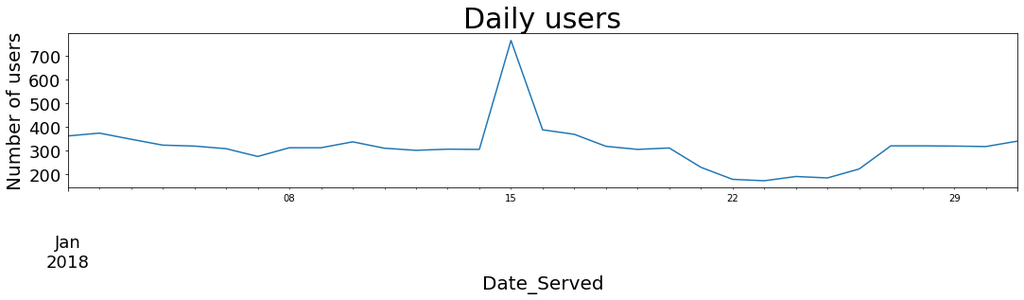

```python
#Visualizing daily marketing reach

# Plot daily_subscribers
daily_users.plot(figsize=(18,3))

# Include a title and y-axis label
plt.title('Daily users',fontsize=30)
plt.ylabel('Number of users', fontsize=20)
plt.xlabel('Date_Served', fontsize=20)

plt.xticks(fontsize=18)
plt.yticks(fontsize=18)

# Rotate the x-axis labels by 45 degrees
#plt.xticks(rotation=45)

# Display the plot
plt.show()
```

As we can see, while the first half of the month sticks around 300 users per day, there's a huge spike in the middle of the month. This may be because we sent out a big marketing email, which reached many users who are not daily visitors of the site.

# Common high-level Marketing Metrics:

#### 1- Conversion Rate

#### 2- Retention Rate

# 1- Conversion Rate

### Conversion Rate:

#### is the percentage of the users who saw our marketing assets and subsequently became subscribers.

### Formula of Conversion Rate:

#### Number of people who converted / Total Number of people we marketed to

### We can start to see the Overall Conversion Rate for the whole campagin to have a quick look to see how much was the campagin successful as a whole.

```python
# Calculate the number of people we marketed to
total = marketing['user_id'].nunique()

# Calculate the number of people who subscribed
subscribers = marketing[marketing['converted'] ==True]['user_id'].nunique()

# Calculate the conversion rate
conversion_rate = subscribers/total
print(round(conversion_rate*100, 2), "%")
```

```
14.09 %
```

As we can see, the overall Conversion Rate for the whole campagin is 14.09 %

# 2- Retention Rate

### Retention Rate :

#### is the percentage of people that remain subscribed from the users who converted to your product after a certain period of time.

##### This can give us a sense of whether our marketing campaign converted subscribers were actually interested in the product.

### Formula of Retention Rate:

#### Number of people who remain subscribed / Total number of people who converted

Here,we will focus on 1-month retention. So, we need to calculate the total number of users who remain subscribers after one month.

### We can start to see the Overall Retention Rate for the whole campagin to have a quick look to see how much was the campagin successful as a whole.

```python
#calculate Retention Rate

# Calculate the number of subscribers
total_subscribers = marketing[marketing['converted']==True]['user_id'].nunique()

# Calculate the number of people who remained subscribed
retained = marketing[marketing['is_retained']==True]['user_id'].nunique()

# Calculate the retention rate
retention_rate = retained/total_subscribers
print(round(retention_rate*100, 2), "%")
```

```
676.41 %
```

### So how do I know if these Conversion and Retention rates are good or bad?

#### The answer is simple: it depends.

#### There is no particular number that all marketing teams are trying to reach. So, there is no Retention rate or Conversion rate that will apply across all businesses and industries. We should look at historical Conversion rates or Retention rates of companies in a similar industry to interpret our results.

# Segmentation

### Common ways to segment customers

##### In addition to high-level metrics, it's important to segment customers by who you're marketing to.

### Segmenting: means breaking down metrics by specific characteristics.

#### For instance, in addition to looking at conversion rates overall, we might also want to look at conversion rate by, for example, age group or by customers' language or subscribing channel and so on.

##### It's possible that a campaign had a low conversion rate overall, but was super effective for users within specific age group for example.

##### Rather than calling the campaign a failure, we can say that our team has learned a new way to market to specific age individuals!. Then, we could use these results to conduct a campaign to market to these very specific age individuals using a different marketing technique than everyone else.

## Comparing language conversion rates

##### Now, The marketing team wants to determine how effective the campaign was on converting English speakers.

So, we will compare the conversion rate for English speakers to the overall conversion rate to gain a sense of how effective the marketing campaign was among this group compared to the overall population.

Then, we will compare English to the rest of the languages in the dataset. to get a sense of which languages convert well relative to others.

```python
# Isolate english speakers
english_speakers = marketing[marketing['language_displayed'] == 'English']

# Calculate the total number of English speaking users
total = english_speakers['user_id'].nunique()

# Calculate the number of English speakers who converted
subscribers = english_speakers[english_speakers['converted']==True]['user_id'].nunique()

# Calculate conversion rate
conversion_rate = subscribers/total
print('English speaker conversion rate:', round(conversion_rate*100,2), '%')
```

```
English speaker conversion rate: 13.13 %
```

# Comparing Conversion Rate across the four languages

Note that while many of our users speak English, some prefer another language. So, Let's check to make sure our marketing material translated well across languages.

Rather than looking at the overall conversion rate, we can analyze metrics by specific demographics like language preference, which allows us to determine whether the marketing campaign was more effective in certain languages.

Now, We can look at the conversion rate by the language that the marketing asset was shown in.

```python
# Group by language_displayed and count unique users
total = marketing.groupby(['language_displayed'])['user_id'].nunique()

# Group by language_displayed and count unique conversions
subscribers = marketing[marketing['converted']==True].groupby(['language_displayed'])['user_id'].nunique()

# Calculate the conversion rate for all languages
language_conversion_rate = subscribers/total
print(language_conversion_rate)
```

```
language_displayed
Arabic     0.500000
English    0.131260
German     0.716216
Spanish    0.200000
Name: user_id, dtype: float64
```

As we can see the marketing assets in German have the highest conversion rate and the marketing assets in English have the Lowest conversion rate.

We can see these results graphically: it will be much easier to compare relative conversion rates visually.

# Visualizing conversion rate by language

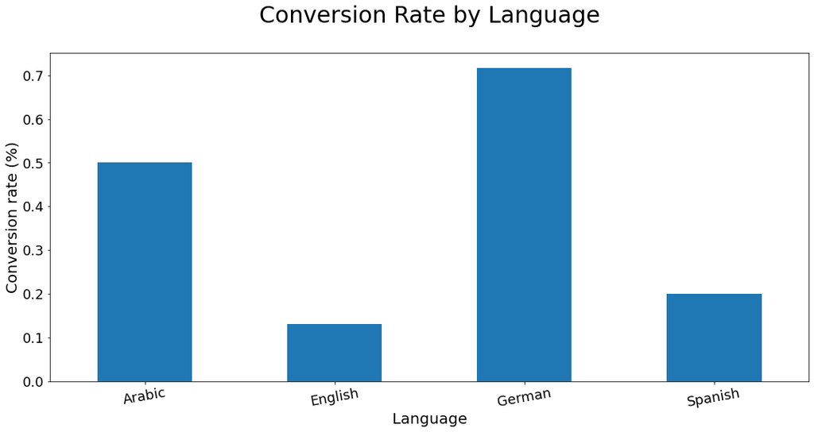

```python
# Create a bar chart using language_conversion_rate for the four languages


language_conversion_rate.plot(kind='bar', figsize=(18,8))

# Add a title and x and y-axis labels
plt.title('Conversion Rate by Language\n', fontsize=30)
plt.xlabel('Language', fontsize=20)
plt.xticks(fontsize=18, rotation=10)
plt.ylabel('Conversion rate (%)', fontsize=20)
plt.yticks(fontsize=18)

# Display the plot
plt.show();
```

This very plot shows that German and Arabic speakers have much higher conversion rates than English and Spanish speakers.

Actually, the conversion rate is much much lower for English and Spanish.

So, we may conduct a deeper investigation into the differences between conversion rate by language later to detect if there is any problem relvant to these languages.

# Aggregating Conversion Rate across time

**Now, we will see how some of the metrics have evolved.**

The marketing team wants to know whether there is any difference in the conversion rate based on "when in the month", our users saw an ad.

If we want to understand how our campaign performed, it is essential to look at how key metrics changed throughout the campaign: Key metrics can help us catch problems that may have happened during the campaign.

Metrics over time can also surface trends like gaining more subscribers over the weekends or on specific holidays.

## Creating daily conversion rate DataFrame

Looking at the daily conversion rate is crucial to contextualize whether the conversion rate on a particular day was good or bad.

Additionally, looking at conversion rate over time can help to surface trends such as a conversion rate that appears to be going down over time.

These kinds of trends are crucial to identify **as early as possible**.

```python
# Group by date_served and count unique users
total = marketing.groupby(['date_served'])['user_id'].nunique()

# Group by date_served and count unique converted users(subscribers)
subscribers = marketing[marketing['converted'] == True].groupby(['date_served'])['user_id'].nunique()

# Calculate the conversion rate per day for all languages
daily_conversion_rates = subscribers/total

print(daily_conversion_rates)
```

```
date_served
2018-01-01    0.099448
2018-01-02    0.098930
2018-01-03    0.103448
2018-01-04    0.108359
2018-01-05    0.125392
2018-01-06    0.113636
2018-01-07    0.141818
2018-01-08    0.115385
2018-01-09    0.125000
2018-01-10    0.118694
2018-01-11    0.080645
2018-01-12    0.076412
2018-01-13    0.084967
2018-01-14    0.085246
2018-01-15    0.113429
2018-01-16    0.255155
2018-01-17    0.219512
2018-01-18    0.091195
2018-01-19    0.059016
2018-01-20    0.067524
2018-01-21    0.087336
2018-01-22    0.123596
2018-01-23    0.122093
2018-01-24    0.115789
2018-01-25    0.125000
2018-01-26    0.090090
2018-01-27    0.065625
2018-01-28    0.062500
2018-01-29    0.059561
2018-01-30    0.066246
2018-01-31    0.052941
Name: user_id, dtype: float64
```

We might notice it's difficult to identify trends using this Series. It will be better to plot the results visually to make interpretation easier.

## Setting up our data to visualize daily conversion

Before we can begin visualizing, we need to transform our data into an easier format to use with pandas and matplotlib.

```python
# Reset index to turn the results into a DataFrame
daily_conversion_rate = pd.DataFrame(daily_conversion_rates.reset_index())

# Rename columns
daily_conversion_rate.columns = ['date_served',
                              'conversion_rate']
daily_conversion_rate.head()
```

|  | date_served | conversion_rate |
| --- | --- | --- |
| 0 | 2018-01-01 | 0.099448 |
| 1 | 2018-01-02 | 0.098930 |
| 2 | 2018-01-03 | 0.103448 |
| 3 | 2018-01-04 | 0.108359 |
| 4 | 2018-01-05 | 0.125392 |

# Visualize daily conversion rate

Now that we formatted the data into a more manageable format for visualization, we will proceed to create a line chart that can make it much easier to notice peaks and valleys in our conversion rate over time.

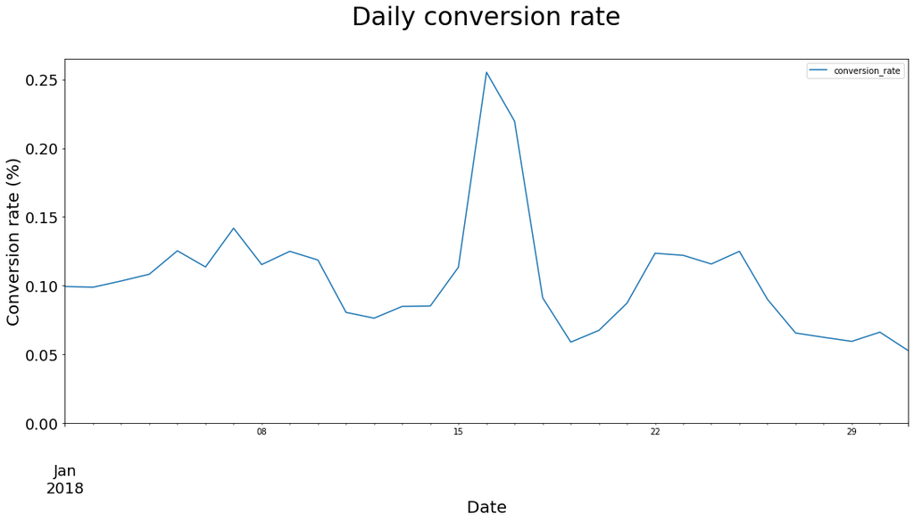

```python
# Create a line chart using daily_conversion_rate

daily_conversion_rate.plot('date_served','conversion_rate', figsize=(18,8))
plt.title('Daily conversion rate\n',fontsize=30)
plt.ylabel('Conversion rate (%)',fontsize=20)
plt.yticks(fontsize=18)
plt.xlabel('Date',fontsize=20)
plt.xticks(fontsize=18)

# Set the y-axis to begin at 0
plt.ylim(0)

# Display the plot
plt.show()
```

Thanks to this line chart, we identified in fast and easy way that the conversion rate is relatively steady except for one day in January.

# Marketing channels Reaching out across age groups

The marketing team wants to know if their marketing channels are reaching all users equally,

or if some marketing channels are serving specific age demographics.

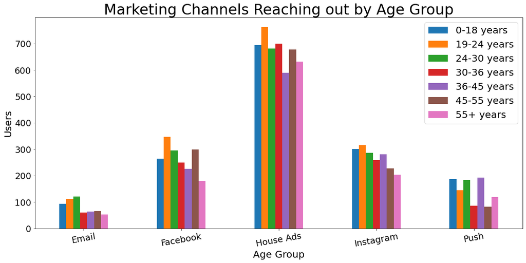

```python
# creating a grouped bar chart showing how many people each marketing channel reached by age group.

channel_age = marketing.groupby(['marketing_channel', 'age_group'])\
                                ['user_id'].count()

# Unstack channel_age and transform it into a DataFrame
channel_age_df = pd.DataFrame(channel_age.unstack(level = 1))

# Plot channel_age
channel_age_df.plot(kind = 'bar', figsize=(18,8))
plt.title('Marketing Channels Reaching out by Age Group',fontsize=30)
plt.xlabel('Age Group',fontsize=20)
plt.xticks(fontsize=18, rotation=10)
plt.ylabel('Users',fontsize=20)
plt.yticks(fontsize=18)
# Add a legend to the plot
plt.legend(loc = 'upper right',
           labels = channel_age_df.columns.values, fontsize=20)
plt.show();
```

# Retention Rate by Subscribing Channel

The team wants to see which channel had the best retention rate from the campaign.

It's important to identify how each marketing channel is performing because this will affect company strategy going forward. If one channel is outperforming others, it might signal the channel merits further investment.

We will calculate the total subscribers and retained subscribers to calculate retention rate.

```python
# Count the subs by subscribing channel and day
retention_total = marketing.groupby(['date_subscribed', 'subscribing_channel'])['user_id'].nunique()

# Print results
print(retention_total.head())
```

```
date_subscribed  subscribing_channel
2018-01-01       Email                   1
                 Facebook                8
                 House Ads              16
                 Instagram               8
                 Push                    3
Name: user_id, dtype: int64
```

```python
# Sum the retained subs by subscribing channel and date subscribed
retention_subs = marketing[marketing['is_retained'] == True].groupby(['date_subscribed', 'subscribing_channel'])['user_id'].nunique()

# Print results
print(retention_subs.head())
```

```
date_subscribed  subscribing_channel
2018-01-01       Email                   1
                 Facebook                7
                 House Ads              11
                 Instagram               6
                 Push                    3
Name: user_id, dtype: int64
```

```python
# Divide retained subscribers by total subscribers
retention_rate = retention_subs/retention_total
retention_rate_df = pd.DataFrame(retention_rate.unstack(level=1))
```

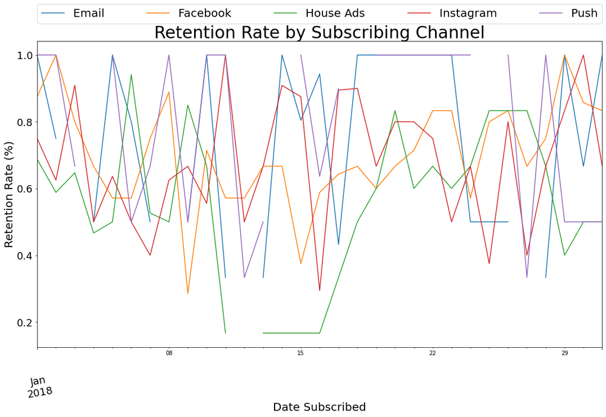

```python
# Plot retention rate
retention_rate_df.plot(figsize=(18,10))

# Add a title, x-label, y-label, legend and display the plot
plt.title('Retention Rate by Subscribing Channel',fontsize=30)
plt.xlabel('Date Subscribed',fontsize=20)
plt.xticks(fontsize=18, rotation=10)

plt.ylabel('Retention Rate (%)',fontsize=20)
plt.yticks(fontsize=18)

plt.legend( labels= retention_rate_df.columns.values, fontsize=20, bbox_to_anchor=(0., 1.02, 1., .102),
           ncol=5, mode="expand", borderaxespad=0.)
plt.show();
```

Now we can see which channels are driving subscribers with the longest retention rate.

# FUNCTIONS

## Creating and Using FUNCTIONS for effeciency

### Creating a Conversion Rate Function

We can build a function to enable us to calculate conversion rate across any sub-segment we want on the fly.

So we will build a function that takes a DataFrame and list of column names and outputs the conversion rate across the column(s).

Then we test out this function.

```python
# see how quickly we can calculate the conversion rate by this function instead of repetitive multiple steps.

def conversion_rate(dataframe, column_names):
    # Total number of converted users
    column_conv = dataframe[dataframe['converted']==True].groupby(column_names)['user_id'].nunique()

    # Total number users
    column_total = dataframe.groupby(column_names)['user_id'].nunique()

    # Conversion rate
    conversion_rate = column_conv/column_total

    # Fill missing values with 0
    conversion_rate = conversion_rate.fillna(0)
    return conversion_rate
```

### Testing out the Conversion Function

### Calculating Conversion Rate across time Per Age Group

So, we will calculate conversion rate by age, then we want to see if that rate has changed over time.

```
date_served  age_group
2018-01-01   0-18 years     0.155172
             19-24 years    0.196721
             24-30 years    0.105263
             30-36 years    0.040816
             36-45 years    0.042553
                              ...
2018-01-31   24-30 years    0.057692
             30-36 years    0.000000
             36-45 years    0.035088
             45-55 years    0.023256
             55+ years      0.026316
Name: user_id, Length: 217, dtype: float64
```

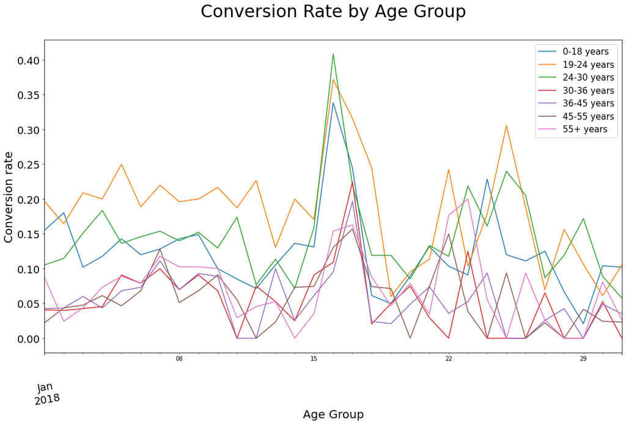

```python
# Calculate conversion rate by age_group
age_group_conv = conversion_rate(marketing, ['date_served', 'age_group'])
print(age_group_conv)

# Unstack and create a DataFrame
age_group_df = pd.DataFrame(age_group_conv.unstack(level=1))

# Visualize conversion by age_group
age_group_df.plot(figsize=(18,10))
plt.title('Conversion Rate by Age Group\n', fontsize=30)
plt.ylabel('Conversion rate', fontsize=20)
plt.yticks(fontsize=18)
plt.xlabel('Age Group', fontsize=20)
plt.xticks(fontsize=18, rotation=10)
plt.legend(labels= age_group_df.columns.values, fontsize=15)
plt.show();
```

We can plot each age group in a seprate visual for easier interpretation.

# Creating Plotting (Visualizing) Function

Building a function to plot the results of the conversion rate resulted from the conversion rate function.

```python
# create a plotting function for visualization
def plotting_conv(dataframe):
    for column in dataframe:
        # Plot column by dataframe's index
        plt.figure(figsize=(15,6))
        plt.plot(dataframe.index,dataframe[column])
        plt.title('Daily ' + str(column) + ' conversion rate\n',
                  fontsize =30)
        plt.ylabel('Conversion rate', fontsize =20)
        plt.xlabel('Date', fontsize =20)
        # Show plot
        plt.show()
        plt.clf()
```

Now, we can quickly generate plots for sub-segments.

# Putting it all together **conversion_rate() & plotting_conv()**

Utilizing these functions to get a quick report of the daily conversion rate for each age group.

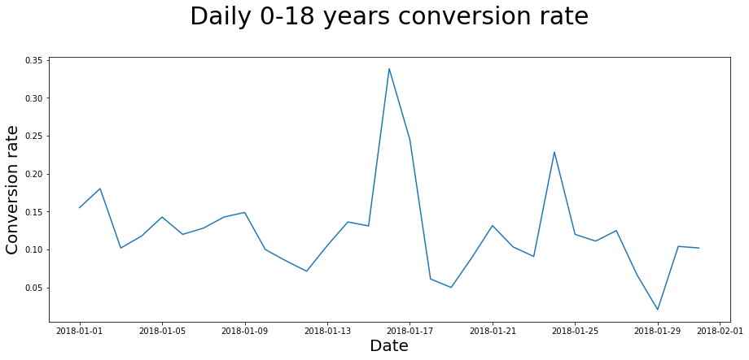

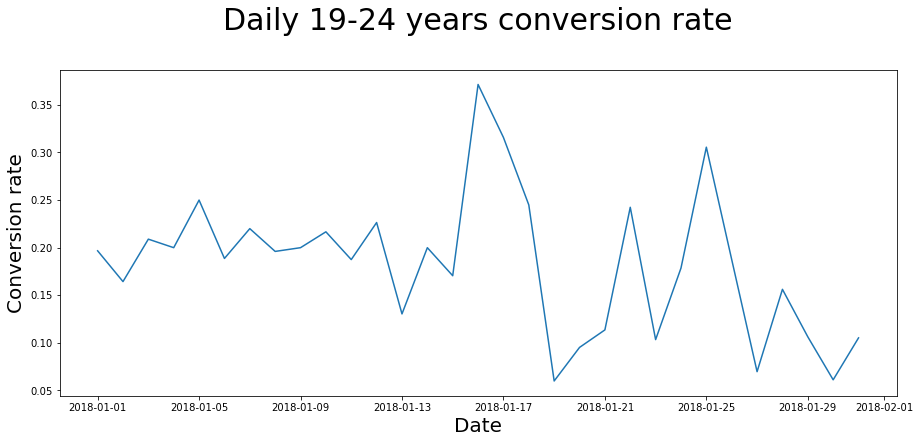

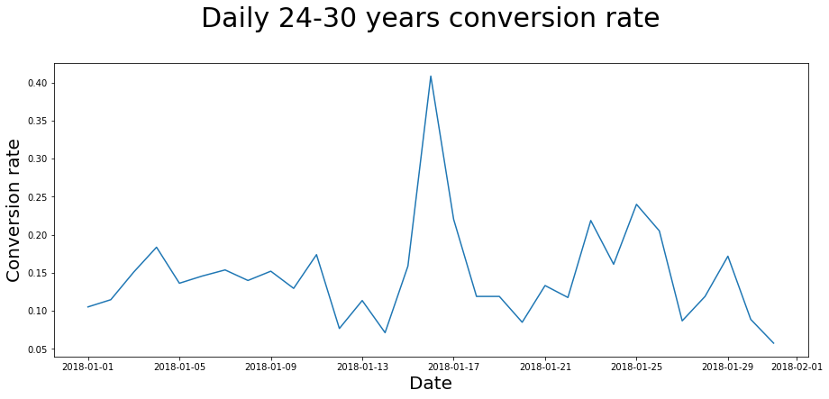

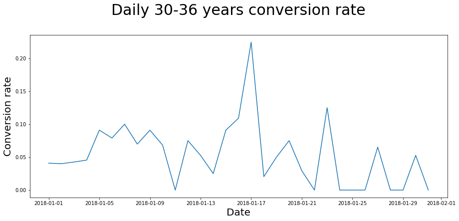

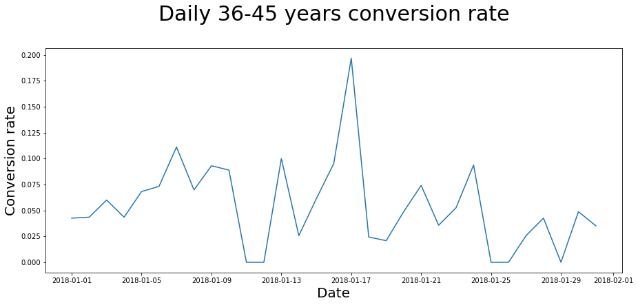

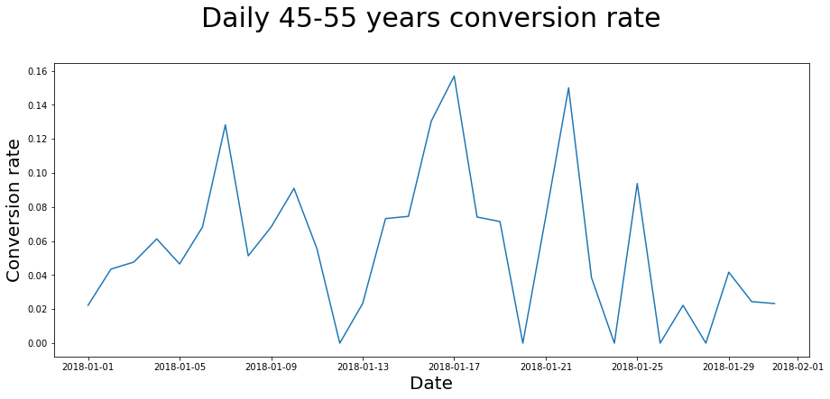

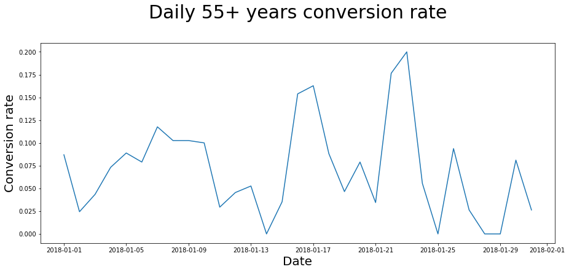

```python
# Calculate conversion rate by date served and age group
age_group_conv = conversion_rate(marketing, ['date_served', 'age_group'])

# Unstack age_group_conv and create a DataFrame
age_group_df = pd.DataFrame(age_group_conv.unstack(level=1))

# Plot the results
plotting_conv(age_group_df)
```

# Identifying INCONSISTENCIES

# House ads Conversion Rate

The house ads team noticed some irregularities in conversion rate. There are some concerns they've noticed around changing metrics.

We will determine whether these changes are natural fluctuations or if they require further investigation.

We will use our created conversion_rate() and plotting_conv() functions.

```
date_served  marketing_channel
2018-01-01   Email                1.000000
             Facebook             0.117647
             House Ads            0.084656
             Instagram            0.106667
             Push                 0.083333
Name: user_id, dtype: float64
```

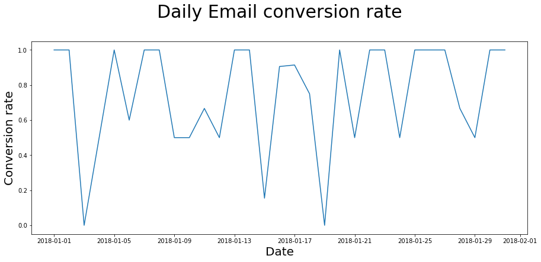

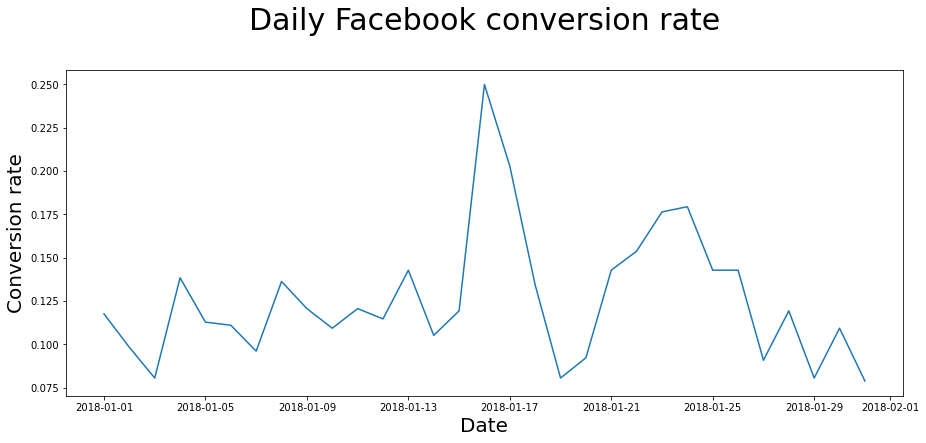

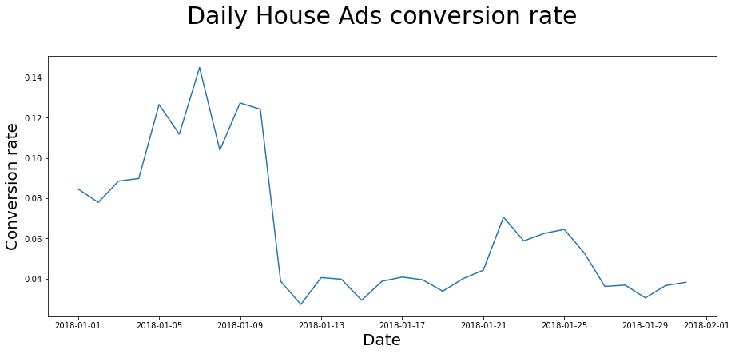

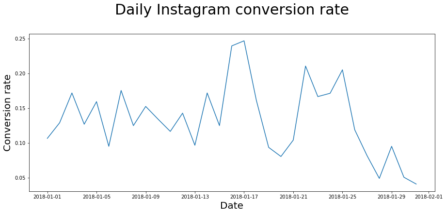

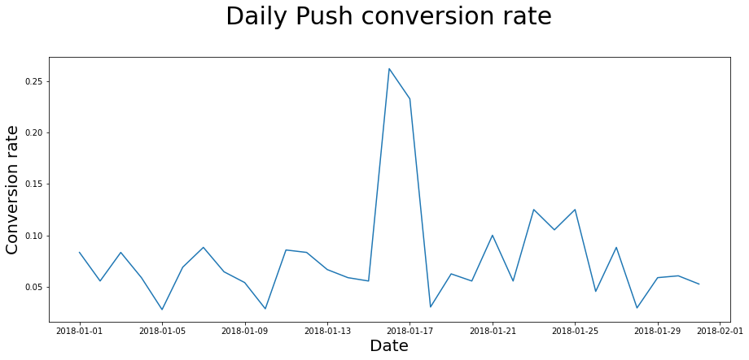

```python
# Calculate conversion rate by date served and channel
daily_conv_channel = conversion_rate(marketing, ['date_served',
                                                 'marketing_channel'])

print(daily_conv_channel.head())

# Unstack daily_conv_channel and convert it to a DataFrame
daily_conv_channel = pd.DataFrame(daily_conv_channel.unstack(level = 1))

# Plot results of daily_conv_channel
plotting_conv(daily_conv_channel)
```

A question arises here:

What do we notice about the house ads conversion rate?

**A sudden decrease in conversion rate starting on January 11**.

Now, let's try to figure out what might be going on with House Ads' conversion rate.

# Analyzing House ads conversion rate

We will try to identify potential causes for the decrease: If the fluctuations in metrics are due to expected shifts in user behavior (i.e., differences across the day of the week) versus a larger problem in technical implementation or marketing strategy.

We will begin by checking whether users are more likely to convert on weekends compared with weekdays and determine if that could be the cause for the changing house ads conversion rate.

```python
# Importing calender library to convert numeric labels of days of week to name labels.
import calendar
list(calendar.day_abbr)
```

```
['Mon', 'Tue', 'Wed', 'Thu', 'Fri', 'Sat', 'Sun']
```

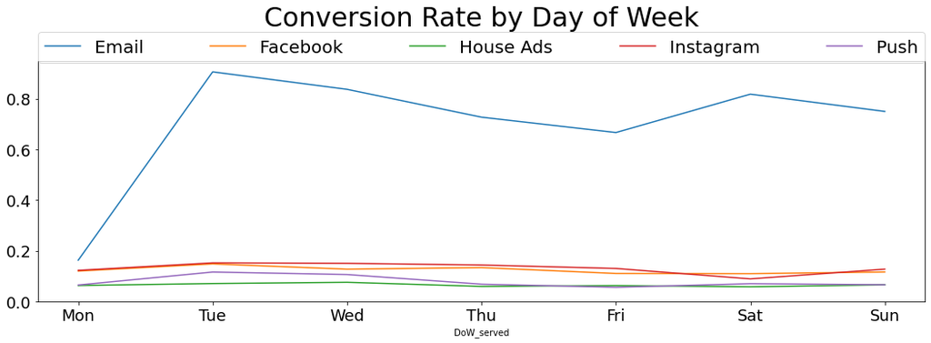

```python
# Add day of week column to marketing
marketing['DoW_served'] = marketing['date_served'].dt.dayofweek

# Calculate conversion rate by day of week
DoW_conversion = conversion_rate(marketing, ['DoW_served', 'marketing_channel'])

# Unstack channels
DoW_df = pd.DataFrame(DoW_conversion.unstack(level=1))

# Plot conversion rate by day of week
DoW_df.plot(figsize=(18,5))
plt.title('Conversion Rate by Day of Week\n',fontsize=30)
plt.xticks(np.arange(7),list(calendar.day_abbr), fontsize=18)
plt.yticks(fontsize=18)


plt.legend( labels= DoW_df.columns.values, fontsize=20, bbox_to_anchor=(0., 1.02, 1., .102),
           ncol=5, mode="expand", borderaxespad=0.)


plt.ylim(0)
plt.show();


# Rotate the x-axis labels by 45 degrees
#plt.xticks(rotation=45)
```

House ads appear stable across the week with a very slight peak on Tuesday.

So, natural fluctuations are ruled out across the day of the week a user saw our marketing assets as they cause for decreasing house ads conversion.

So, We have to investigate further: we will take a look at conversion by language over time.

# House ads conversion by language

Perhaps the new marketing campaign does not apply broadly across different cultures.

Ideally, the marketing team will consider cultural differences prior to launching a campaign, but sometimes mistakes are made.

We will try to identify the cause and what went wrong with the marketing campaign.

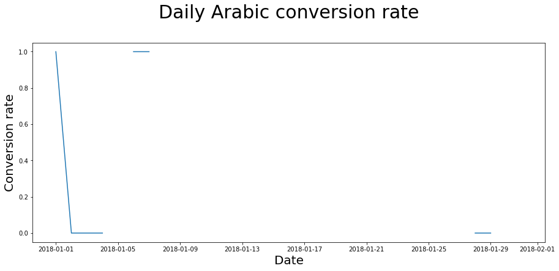

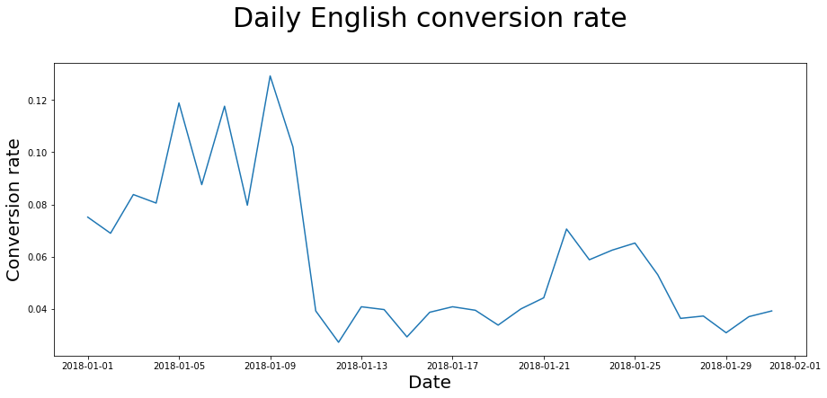

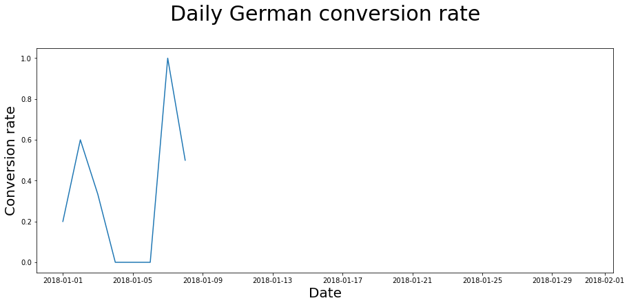

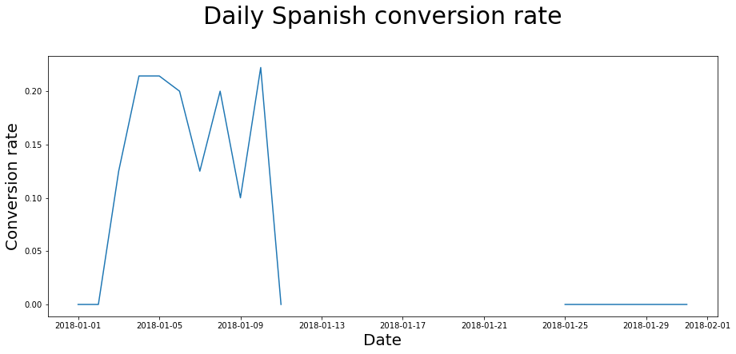

```python
# Isolate the rows where marketing channel is House Ads
house_ads = marketing[marketing['marketing_channel']== 'House Ads']

# Calculate conversion by date served, and language displayed
conv_lang_channel = conversion_rate(house_ads, ['date_served', 'language_displayed'])

# Unstack conv_lang_channel
conv_lang_df = pd.DataFrame(conv_lang_channel.unstack(level=1))

# Use your plotting function to display results
plotting_conv(conv_lang_df)
```

WHAT!!! There is a BIG ALARM here.

As we can see, the English conversion rate drops around the 11th, and there do not appear to be ads served in other languages for around a two week period.

We HAVE TO investigate further.

# Analyzing the house ads more...

We noticed a pattern around language preferences.

So, We need to see what went wrong to correct the problem and not repeat the mistake again if any.

We will create a DataFrame that checks whether users see ads in the correct language they prefer or not.

```python
# Add the new column is_correct_lang
house_ads['is_correct_lang'] = np.where(
    house_ads['language_displayed'] == house_ads['language_preferred'],
    'Yes',
    'No')

# Groupby date_served and correct_language
language_check = house_ads.groupby(['date_served', 'is_correct_lang'])['user_id'].count()

# Unstack language_check and fill missing values with 0's
language_check_df = pd.DataFrame(language_check.unstack(level=1)).fillna(0)

# Print results
print(language_check_df.head(15))
```

```
is_correct_lang    No    Yes
date_served
2018-01-01        2.0  189.0
2018-01-02        3.0  247.0
2018-01-03        0.0  220.0
2018-01-04        0.0  168.0
2018-01-05        0.0  160.0
2018-01-06        1.0  151.0
2018-01-07        2.0  130.0
2018-01-08        0.0  154.0
2018-01-09        0.0  157.0
2018-01-10        0.0  170.0
2018-01-11       20.0  135.0
2018-01-12       18.0  130.0
2018-01-13       26.0  122.0
2018-01-14       20.0  131.0
2018-01-15       16.0  192.0
```

It seems that the value of 'NO' in the newly created column 'is_correct_lang' is 0, 1, 2 or 3 as maximum from the beginnig of the month until the 10th day. Then starting from 11th the numbers jumped high suddenly.

# Confirming house ads error

Let's calculate: "what percentage of users were being served ads in the right language" and plot the results.

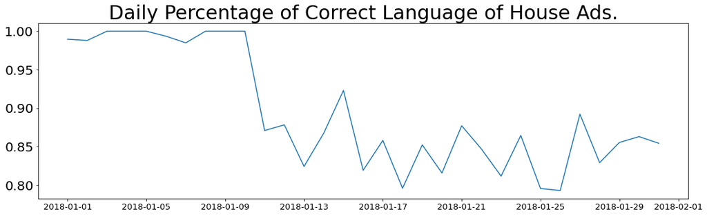

```python
# Divide the count where language is correct by the row sum
language_check_df['pct'] = language_check_df['Yes']/ language_check_df.sum(axis=1)

# Plot and show your results
plt.figure(figsize=(18,5))

plt.plot(language_check_df.index, language_check_df['pct'])
plt.title('Daily Percentage of Correct Language of House Ads.', fontsize=30)
plt.xticks(fontsize=13)
plt.yticks(fontsize=20)
plt.show()
```

As we can see right now the house ads have been underperforming due to serving all ads in English rather than each user's preferred language.

# More of House Ads. Investigation

# Setting up conversion indexes

After we've determined that language is, in fact, the issue with House Ads conversion, the marketing team needs to know how many subscribers they lost as a result of this bug.

So we will index non-English language conversion rates against English conversion rates in the time period before the language bug arose.

```python
# Calculate pre-error conversion rate
house_ads_bug = house_ads[house_ads['date_served'] < '2018-01-11']
lang_conv = conversion_rate(house_ads_bug, 'language_displayed')

# Index other language conversion rate against English
spanish_index = lang_conv['Spanish']/lang_conv['English']
arabic_index = lang_conv['Arabic']/lang_conv['English']
german_index = lang_conv['German']/lang_conv['English']

print('The conversion rate per language before the problem occurred:')
print(lang_conv.head())

print("Spanish index:", spanish_index)
print("Arabic index:", arabic_index)
print("German index:", german_index)
```

```
The conversion rate per language before the problem occurred:
language_displayed
Arabic     0.500000
English    0.099093
German     0.444444
Spanish    0.166667
Name: user_id, dtype: float64
Spanish index: 1.681924882629108
Arabic index: 5.045774647887324
German index: 4.485133020344287
```

Now we can assess what conversion rate should have been during the rest of the month.

# Analyzing user preferences

To understand the true impact of the bug, it is crucial to determine how many subscribers we would have expected if there was no language error.

This is crucial to understanding the scale of the problem and how important it is to prevent this kind of error in the future.

```python
# Checking house_ads dataframe
#house_ads.head(1)
```

```python
#This DataFrame includes how many users prefer each language by day.

# Group house_ads by date and language
converted = house_ads.groupby(['date_served', 'language_preferred'])\
                        .agg({'user_id':'nunique',
                              'converted':'sum'})

# Unstack converted
converted = pd.DataFrame(converted.unstack(level = 1))

converted.head(15)
```

| language_preferred date_served | user_id Arabic | user_id English | user_id German | user_id Spanish | converted Arabic | converted English | converted German | converted Spanish |
| --- | --- | --- | --- | --- | --- | --- | --- | --- |
| 2018-01-01 | 2.0 | 171.0 | 5.0 | 11.0 | 2.0 | 13.0 | 1.0 | 0.0 |
| 2018-01-02 | 3.0 | 200.0 | 5.0 | 10.0 | 0.0 | 14.0 | 3.0 | 0.0 |
| 2018-01-03 | 2.0 | 179.0 | 3.0 | 8.0 | 0.0 | 15.0 | 1.0 | 1.0 |
| 2018-01-04 | 2.0 | 149.0 | 2.0 | 14.0 | 0.0 | 12.0 | 0.0 | 3.0 |
| 2018-01-05 | NaN | 143.0 | 1.0 | 14.0 | NaN | 17.0 | 0.0 | 3.0 |
| 2018-01-06 | 3.0 | 136.0 | 2.0 | 11.0 | 3.0 | 12.0 | 0.0 | 2.0 |
| 2018-01-07 | 2.0 | 117.0 | 2.0 | 10.0 | 2.0 | 14.0 | 2.0 | 1.0 |
| 2018-01-08 | NaN | 138.0 | 6.0 | 10.0 | NaN | 11.0 | 3.0 | 2.0 |
| 2018-01-09 | NaN | 147.0 | NaN | 10.0 | NaN | 19.0 | NaN | 1.0 |
| 2018-01-10 | NaN | 147.0 | 4.0 | 18.0 | NaN | 15.0 | 2.0 | 4.0 |
| 2018-01-11 | 7.0 | 133.0 | 2.0 | 13.0 | 0.0 | 6.0 | 0.0 | 0.0 |
| 2018-01-12 | 3.0 | 129.0 | 4.0 | 11.0 | 0.0 | 3.0 | 0.0 | 1.0 |
| 2018-01-13 | 6.0 | 121.0 | 5.0 | 16.0 | 0.0 | 5.0 | 1.0 | 0.0 |
| 2018-01-14 | 5.0 | 131.0 | 3.0 | 12.0 | 0.0 | 6.0 | 0.0 | 0.0 |
| 2018-01-15 | 2.0 | 189.0 | 4.0 | 10.0 | 0.0 | 6.0 | 0.0 | 0.0 |

# Calculating daily expected conversion

We can begin calculating how many subscribers we would have expected to have if the language bug did not occurr.

# Creating a DataFrame based on indexes

This DataFrame will estimate what daily conversion rates should have been if users were being served the correct language.

The DataFrame 'converted' contains expected subscribers columns for Spanish, Arabic and German language speakers named expected_spanish_conv, expected_arabic_conv and expected_german_conv respectively.

```python
# Create English conversion rate column for affected period
converted['english_conv_rate'] = converted.loc['2018-01-11': '2018-01-31'][('converted', 'English')]

# Create expected conversion rates for each language
converted['expected_spanish_rate'] = converted['english_conv_rate']*spanish_index
converted['expected_arabic_rate'] = converted['english_conv_rate']*arabic_index
converted['expected_german_rate'] = converted['english_conv_rate']*german_index

# Multiply number of users by the expected conversion rate
converted['expected_spanish_conv'] = converted[('user_id', 'Spanish')]*converted['expected_spanish_rate']/100
converted['expected_arabic_conv'] = converted[('user_id', 'Arabic')]*converted['expected_arabic_rate']/100
converted['expected_german_conv'] = converted[('user_id', 'German')]*converted['expected_german_rate']/100

converted.head(15)
```

| language_preferred date_served | user_id Arabic | user_id English | user_id German | user_id Spanish | converted Arabic | converted English | converted German | converted Spanish | english_conv_rate | expected_spanish_rate | expected_arabic_rate | expected_german_rate | expected_spanish_conv | expected_arabic_conv | expected_german_conv |
| --- | --- | --- | --- | --- | --- | --- | --- | --- | --- | --- | --- | --- | --- | --- | --- |
| 2018-01-01 | 2.0 | 171.0 | 5.0 | 11.0 | 2.0 | 13.0 | 1.0 | 0.0 | NaN | NaN | NaN | NaN | NaN | NaN | NaN |
| 2018-01-02 | 3.0 | 200.0 | 5.0 | 10.0 | 0.0 | 14.0 | 3.0 | 0.0 | NaN | NaN | NaN | NaN | NaN | NaN | NaN |
| 2018-01-03 | 2.0 | 179.0 | 3.0 | 8.0 | 0.0 | 15.0 | 1.0 | 1.0 | NaN | NaN | NaN | NaN | NaN | NaN | NaN |
| 2018-01-04 | 2.0 | 149.0 | 2.0 | 14.0 | 0.0 | 12.0 | 0.0 | 3.0 | NaN | NaN | NaN | NaN | NaN | NaN | NaN |
| 2018-01-05 | NaN | 143.0 | 1.0 | 14.0 | NaN | 17.0 | 0.0 | 3.0 | NaN | NaN | NaN | NaN | NaN | NaN | NaN |
| 2018-01-06 | 3.0 | 136.0 | 2.0 | 11.0 | 3.0 | 12.0 | 0.0 | 2.0 | NaN | NaN | NaN | NaN | NaN | NaN | NaN |
| 2018-01-07 | 2.0 | 117.0 | 2.0 | 10.0 | 2.0 | 14.0 | 2.0 | 1.0 | NaN | NaN | NaN | NaN | NaN | NaN | NaN |
| 2018-01-08 | NaN | 138.0 | 6.0 | 10.0 | NaN | 11.0 | 3.0 | 2.0 | NaN | NaN | NaN | NaN | NaN | NaN | NaN |
| 2018-01-09 | NaN | 147.0 | NaN | 10.0 | NaN | 19.0 | NaN | 1.0 | NaN | NaN | NaN | NaN | NaN | NaN | NaN |
| 2018-01-10 | NaN | 147.0 | 4.0 | 18.0 | NaN | 15.0 | 2.0 | 4.0 | NaN | NaN | NaN | NaN | NaN | NaN | NaN |
| 2018-01-11 | 7.0 | 133.0 | 2.0 | 13.0 | 0.0 | 6.0 | 0.0 | 0.0 | 6.0 | 10.091549 | 30.274648 | 26.910798 | 1.311901 | 2.119225 | 0.538216 |
| 2018-01-12 | 3.0 | 129.0 | 4.0 | 11.0 | 0.0 | 3.0 | 0.0 | 1.0 | 3.0 | 5.045775 | 15.137324 | 13.455399 | 0.555035 | 0.454120 | 0.538216 |
| 2018-01-13 | 6.0 | 121.0 | 5.0 | 16.0 | 0.0 | 5.0 | 1.0 | 0.0 | 5.0 | 8.409624 | 25.228873 | 22.425665 | 1.345540 | 1.513732 | 1.121283 |
| 2018-01-14 | 5.0 | 131.0 | 3.0 | 12.0 | 0.0 | 6.0 | 0.0 | 0.0 | 6.0 | 10.091549 | 30.274648 | 26.910798 | 1.210986 | 1.513732 | 0.807324 |
| 2018-01-15 | 2.0 | 189.0 | 4.0 | 10.0 | 0.0 | 6.0 | 0.0 | 0.0 | 6.0 | 10.091549 | 30.274648 | 26.910798 | 1.009155 | 0.605493 | 1.076432 |

Now, we will assess how many subscribers we lost due to the language problem.

# Assessing bug impact

It's time to calculate how many subscribers were lost due to mistakenly serving users English rather than their preferred language.

After estimating of the impact of this error, we can determine whether it's worth putting additional checks in place to avoid this in the future.

```python
# Use .loc to slice only the relevant dates
converted = converted.loc['2018-01-11':'2018-01-31']

# Sum expected subscribers for each language
expected_subs = converted['expected_spanish_conv'].sum() + converted['expected_arabic_conv'].sum() + converted['expected_german_conv'].sum()

# Calculate how many subscribers we actually got
actual_subs = converted[('converted', 'Spanish')].sum() + converted[('converted', 'Arabic')].sum() + converted[('converted', 'German')].sum()

# Subtract how many subscribers we got despite the bug
lost_subs = expected_subs - actual_subs
print("The number of lost subscribers: ", lost_subs)
```

```
The number of lost subscribers:  32.144143192488265
```

**32 subscribers** may not seem like many, but for a small company this can be vitally important, especially when expanding to new markets.

# A/B TESTING

## Determining key metrics

The earlier you define what success looks like, the better. So, when designing the experiment, it is good to determine key success metrics.

# Personalized Email V.s Generic Email

The focus of the following cells will be the A/B test that was run where half the emails sent were generic upsells to our product while the other half contained personalized messaging around individual usage of our site.

# Test allocation

One of the things we should check is relatively equal number of users were allocated to each variant. So, before we begin analyzing the results, we will check to ensure users were allocated equally to the test and control groups.

```
        user_id date_served marketing_channel          variant  converted  \
354  a100000526  2018-01-01             Email  personalization       True
358  a100000530  2018-01-05             Email  personalization       True
362  a100000534  2018-01-09             Email  personalization      False
366  a100000538  2018-01-13             Email  personalization       True
370  a100000542  2018-01-17             Email  personalization       True

    language_displayed language_preferred    age_group date_subscribed  \
354             Arabic             Arabic   0-18 years      2018-01-01
358             Arabic             Arabic  19-24 years      2018-01-05
362            English            English  45-55 years      2018-01-09
366             Arabic             Arabic  24-30 years      2018-01-13
370            English            English   0-18 years      2018-01-17

    date_canceled subscribing_channel  is_retained  DoW_served
354           NaT               Email         True         0.0
358           NaT               Email         True         4.0
362           NaT               Email         True         1.0
366    2018-01-23               Email        False         5.0
370    2018-02-12               Email        False         2.0
```

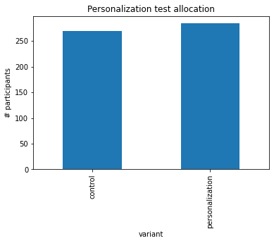

```python
# The DataFrame email contains only rows from the marketing DataFrame where marketing_channel is 'Email'.

# Subset the DataFrame
email = marketing[marketing['marketing_channel']== 'Email']

print(email.head())

# Group the email DataFrame by variant
alloc = email.groupby(['variant'])['user_id'].nunique()

# Plot a bar chart of the test allocation
alloc.plot(kind='bar')
plt.title('Personalization test allocation')
plt.ylabel('# participants')
plt.show()
```

There's a slight difference in allocation, so we can continue with our analysis.

# Comparing conversion rates (personalization & control)

Let's look at the conversion rate for the control and personalization.

We choose conversion rate as our key metric for this test. So, we will evaluate whether or not conversion was higher in the personalization treatment compared with the control.

Measuring the difference between the key metric in the control and the treatment is the most important part of evaluating the success of an A/B test.

```python
# ensuring each user and variant has only one subscription outcome by using the groupby() and max() methods.

# Group marketing by user_id and variant
subscribers = email.groupby(['user_id',
                             'variant'])['converted'].max()
subscribers_df = pd.DataFrame(subscribers.unstack(level=1))

# Drop missing values from the control column to only include conversion outcomes for all users in each variant.
control = subscribers_df['control'].dropna()

# Drop missing values from the personalization column
personalization = subscribers_df['personalization'].dropna()

#calculate the conversion rate by taking the mean of each Series
print('Control conversion rate:', np.mean(control))
print('Personalization conversion rate:', np.mean(personalization))
subscribers_df
```

```
Control conversion rate: 0.2814814814814815
Personalization conversion rate: 0.3908450704225352
```

| variant user_id | control | personalization |
| --- | --- | --- |
| a100000526 | NaN | True |
| a100000530 | NaN | True |
| a100000534 | NaN | False |
| a100000538 | NaN | True |
| a100000542 | NaN | True |
| ... | ... | ... |
| a100007288 | True | NaN |
| a100007289 | True | NaN |
| a100007290 | True | NaN |
| a100007291 | True | NaN |
| a100007293 | True | NaN |

553 rows × 2 columns

We can see that personalization converted users at a higher rate than the control. The question now is by how much.

So, we will build a lift function to quantify by how much.

# Calculating "Lift" to quantify by how much the conversion rate higher for the treatment

- What's the lift?

In this situation, it means **"Was the conversion rate higher for the treatment and by how much?"**.

Lift is calculated by taking the difference between the treatment conversion rate and the control conversion rate divided by the control conversion rate.

The result is **the relative percent difference of treatment compared to control**.

**The formula of calculating lift:**

**(Treatment Conversion Rate - Control Conversion Rate) / Control Conversion Rate**

```python
# Creating a lift function
# create a function to automate the process of calculating lift.

def lift(a,b):
    # Calcuate the mean of a and b
    a_mean = np.mean(a)
    b_mean = np.mean(b)

    # Calculate the lift using a_mean and b_mean
    lift = (b_mean-a_mean)/a_mean

    return str(round(lift*100, 2)) + '%'

# Print lift() with control and personalization as inputs
print(lift(control, personalization))
```

```
38.85%
```

As we can see, there's a large lift. The personalization variant improved on the control conversion rate by 38.85%. That's a huge improvement and a very good signal that we should consider running personalized emails again in the future.

But are our results statistically significant?

It's time for us to determine whether the result is statistically significant.

**Statistical significance is vital to understanding whether a test showed a positive result by chance or if it is reflective of a true difference between the variants.** This will enable the marketing team to make an informed choice about whether to roll out the feature or not.

- T-distribution

One way to calculate statistical significance is by conducting a two-sample t-test.

A t-test uses the mean and the sample variance to determine the likelihood that the variation between the two samples occurred by chance.

- P-value The t-test gives us a t-statistic and a p-value

Remember, a p-value less than 0.05 is typically considered statistically significant at 95% significance level.

```python
# Evaluating statistical significance

# using the ttest_ind() function from the stats module of the scipy package. The function takes a list of outcomes for each
#variant. In this case, the "outcomes" are whether or not each user converted. Using control and personalization as the inputs.
from scipy.stats import ttest_ind
ttest_ind(control, personalization)
```

```
Ttest_indResult(statistic=-2.7343299447505074, pvalue=0.006451487844694175)
```

Is the difference between the control and personalization statistically significant?

Yes, the results are statistically significant with p = 0.006. The personalization results are highly statistically significant.

Since the p-value here is indeed less than 0.05, we can be confident that the difference in conversion rates is statistically significant.

#### We should explore whether that holds up across all demographics.

# A/B Testing & Segmentation

One of the most common pitfalls in A/B testing is assuming that a treatment equally affects everyone in a population.

### Segmentation! (Not all customers are alike!)

Just like with any other kind of marketing, some treatments are particularly effective on users of a specific engagement level, age, race, or any other factor and these treatments may not be effective for other users as well.

Often a treatment will not affect all people uniformly. Some people will love a particular marketing campaign while others hate it. The marketing team has to target users according to their preferences.

So, it is important to break down results by various demographics in order to obtain an understanding of the impact of the test.

# Creating an A/B test segmenting function

Since we want to segment our data multiple times, we will build a function ab_segmentation() that analyzes the impact of our A/B tests on segments of data that we can reuse in this kind of analysis.

```python
# The function takes in a column name and run through each unique value in that column
# calculating lift and statistical significance.


def ab_segmentation(segment):
  #for loop for each subsegment in marketing  to calculate lift and statistical significance across multiple segments of users.

  for subsegment in np.unique(marketing[segment].values):
        print(subsegment)

      # Limit marketing to email and subsegment
        email = marketing[(marketing['marketing_channel'] == 'Email') & (marketing[segment] == subsegment)]

        subscribers = email.groupby(['user_id', 'variant'])['converted'].max()
        subscribers = pd.DataFrame(subscribers.unstack(level=1))
        control = subscribers['control'].dropna()
        personalization = subscribers['personalization'].dropna()

        print('lift:', lift(control, personalization))
        print('t-statistic:', ttest_ind(control, personalization), '\n\n')
```

# Using "ab_segmentation()" function

We will run through two segments in our data that may be relevant to assessing the impact of our test.

- Language & Age Group

# calculating lift and statistical significance by language

When using the ab_segmentation() function, remember to input the column name in quotes (i.e., 'language_displayed')

```python
# Use ab_segmentation on language displayed
ab_segmentation('language_displayed')
```

```
Arabic
lift: 50.0%
t-statistic: Ttest_indResult(statistic=-0.5773502691896255, pvalue=0.5795840000000001)


English
lift: 39.0%
t-statistic: Ttest_indResult(statistic=-2.2183598646203166, pvalue=0.026991701290720815)


German
lift: -1.62%
t-statistic: Ttest_indResult(statistic=0.1910083418078718, pvalue=0.8494394170062678)


Spanish
lift: 166.67%
t-statistic: Ttest_indResult(statistic=-2.3570226039551585, pvalue=0.040156718110477524)
```

### The test performed very well among English and Spanish speakers, while the other language's results are not statistically significant.

### These are the kinds of differences across groups that are crucial to the marketing team to keep an eye out for.

# calculating lift and statistical significance by Age

```python
# Use ab_segmentation on age group
ab_segmentation('age_group')
```

```
0-18 years
lift: 121.4%
t-statistic: Ttest_indResult(statistic=-2.966044912142211, pvalue=0.0038724494391297226)


19-24 years
lift: 106.24%
t-statistic: Ttest_indResult(statistic=-3.03179438478667, pvalue=0.0030623836114689134)


24-30 years
lift: 161.19%
t-statistic: Ttest_indResult(statistic=-3.861539544326876, pvalue=0.00018743381094867337)


30-36 years
lift: -100.0%
t-statistic: Ttest_indResult(statistic=3.1859064644147996, pvalue=0.0023238487431765137)


36-45 years
lift: -85.23%
t-statistic: Ttest_indResult(statistic=2.4317901279318503, pvalue=0.01797568600978829)


45-55 years
lift: -72.22%
t-statistic: Ttest_indResult(statistic=2.065499127317933, pvalue=0.043062339688201196)


55+ years
lift: -100.0%
t-statistic: Ttest_indResult(statistic=3.3265654564203397, pvalue=0.0016358623456360435)
```

### Personalization was extremely effective for younger groups but less effective than the control for older groups.

### One explanation might be that younger users understand how their data might be used online and think personalization is cool because it gives them more insight into themselves while older people might feel that this is a violation of their privacy.

# While the test was a success overall, personalization was not appreciated in certain regions and by certain age groups.